# We can measure how much Edmonton property *should* be tax-exempt. We cannot say which.

## 5. Why this cannot be turned into a list of exempt properties

Three separate obstacles. Any one of them would be enough.

### 5.1 The candidate set does not balance — in the wrong direction

If exempt property were exactly "everything on those five zones", the candidate total would equal the gap. It does not.

```python
nr = gaps.loc["non_residential"]
short = nr["gap"] - nr["on_candidate"]
print(f"non-residential gap:                      ${nr['gap']:,.0f}")
print(f"non-res value on candidate zoning:        ${nr['on_candidate']:,.0f}")
print(f"shortfall:                                ${short:,.0f}  "
      f"({100 * short / nr['gap']:.1f}% of the gap)")
```

```
non-residential gap:                      $8,977,519,042
non-res value on candidate zoning:        $8,677,504,255
shortfall:                                $300,014,787  (3.3% of the gap)
```

The candidate set is *smaller* than the gap. So even granting the most generous reading — that every square metre of those five zones is exempt — there is still property being exempted somewhere else.

A single aggregate cannot separate two errors that offset each other.

### 5.2 For apartments, zoning is the wrong instrument entirely

Alberta's *Municipal Government Act* s.362 exempts property by **use and ownership**, not by zone: seniors' housing, non-profit and subsidised housing, and residences owned by charitable bodies. A non-profit seniors' residence sits on ordinary residential zoning, indistinguishable in the polygon layer from the market apartment block next door.

```python
ap = gaps.loc["other"]
invisible = ap["gap"] - ap["on_candidate"]
apartments = roll[(roll["av_other"] > 0) & (~roll["candidate"])]

print(f"apartment gap:                           ${ap['gap']:,.0f}")
print(f"  explained by candidate zoning:         ${ap['on_candidate']:,.0f}  "
      f"({100 * ap['on_candidate'] / ap['gap']:.1f}%)")
print(f"  invisible to zoning:                   ${invisible:,.0f}  "
      f"({100 * invisible / ap['gap']:.1f}%)")
print(f"\napartment properties on ordinary zoning:  {len(apartments):,}")
print(f"  their combined assessed value:         ${apartments['av_other'].sum():,.0f}")
print(f"  median value:                          ${apartments['av_other'].median():,.0f}")

check(invisible > 0,
      "most of the apartment gap sits on zoning that carries no exemption signal")
```

```
apartment gap:                           $4,005,456,677
  explained by candidate zoning:         $509,471,865  (12.7%)
  invisible to zoning:                   $3,495,984,812  (87.3%)

apartment properties on ordinary zoning:  4,403
  their combined assessed value:         $22,513,412,862
  median value:                          $1,423,000
  [PASS] most of the apartment gap sits on zoning that carries no exemption signal
```

### 5.3 The identification problem — one equation, thousands of unknowns

This is the obstacle that no additional cleverness removes.

What we have is a **single number**: the aggregate gap. What we want is a **per-parcel flag**. Any set of parcels whose values sum to the gap is perfectly consistent with everything published — and there are enormously many such sets.

That is not a hand-wave. Below, two sets of apartment properties are constructed that **share not one property between them**, and each reproduces the invisible apartment gap to within a rounding error. Nothing in any public dataset prefers one over the other.

```python
values = apartments["av_other"].to_numpy()
rng = np.random.default_rng(11)
shuffled = rng.permutation(len(values))
left, right = shuffled[: len(values) // 2], shuffled[len(values) // 2:]


def subset_reaching(vals: np.ndarray, target: float) -> tuple[np.ndarray, float]:
    """Greedy largest-first selection summing as close to target as possible."""
    picked, total = [], 0.0
    for i in np.argsort(-vals):
        if total + vals[i] <= target:
            picked.append(i)
            total += vals[i]
    return np.array(picked, dtype=int), total


pick_a, total_a = subset_reaching(values[left], invisible)
pick_b, total_b = subset_reaching(values[right], invisible)

accounts_a = set(apartments.iloc[left[pick_a]]["account"])
accounts_b = set(apartments.iloc[right[pick_b]]["account"])

print(f"target — apartment exemption invisible to zoning: ${invisible:,.0f}\n")
print(f"  set A: {len(accounts_a):>4,} properties   ${total_a:,.0f}   "
      f"({100 * total_a / invisible:.4f}% of target)")
print(f"  set B: {len(accounts_b):>4,} properties   ${total_b:,.0f}   "
      f"({100 * total_b / invisible:.4f}% of target)")
print(f"  properties in common: {len(accounts_a & accounts_b)}")

check(len(accounts_a & accounts_b) == 0,
      "the two sets are disjoint — no property appears in both")
check(abs(total_a - total_b) / invisible < 0.01,
      "both sets reproduce the same aggregate to within 1%")
```

```
target — apartment exemption invisible to zoning: $3,495,984,812

  set A:   69 properties   $3,495,984,710   (100.0000% of target)
  set B:   57 properties   $3,495,984,805   (100.0000% of target)
  properties in common: 0
  [PASS] the two sets are disjoint — no property appears in both
  [PASS] both sets reproduce the same aggregate to within 1%
```

Two disjoint answers, equally consistent with every published number. And these are just two of the astronomically many that exist — the greedy construction above is not searching for near-misses, it is stumbling onto them immediately from a random split.

**The aggregate constrains the total. It does not constrain the membership.**

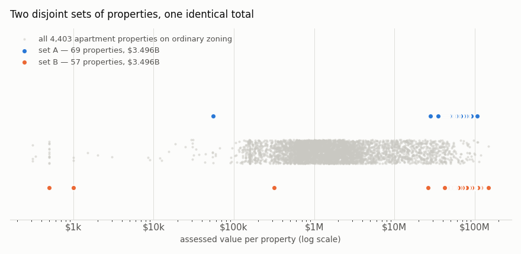

```python
# --- chart 3 ---------------------------------------------------------------
# Form: identity across two constructed sets against a background population
# -> strip plot on a log value axis (values span five orders of magnitude).
# Two series, so a legend is present; blue/orange are validated slots 1-2 and
# clear the all-pairs CVD floor. The background is deliberately neutral ink,
# not a third hue: it is context, not a category.
fig, ax = plt.subplots(figsize=(8, 3.9), facecolor=SURFACE)
ax.set_facecolor(SURFACE)

jitter = rng.uniform(-0.14, 0.14, len(values))
ax.scatter(values, jitter, s=7, color="#c9c8c2", alpha=0.55, linewidths=0,
           label=f"all {len(values):,} apartment properties on ordinary zoning")

va, vb = values[left[pick_a]], values[right[pick_b]]
ax.scatter(va, np.full(len(va), 0.42), s=34, color=BLUE,
           edgecolors=SURFACE, linewidths=1.2, zorder=3,
           label=f"set A — {len(va)} properties, ${total_a / 1e9:.3f}B")
ax.scatter(vb, np.full(len(vb), -0.42), s=34, color=ORANGE,
           edgecolors=SURFACE, linewidths=1.2, zorder=3,
           label=f"set B — {len(vb)} properties, ${total_b / 1e9:.3f}B")

ax.set_xscale("log")
# Headroom above the set-A row so the legend cannot sit on top of its markers.
ax.set_ylim(-0.8, 1.45)
ax.set_yticks([])
ax.xaxis.set_major_formatter(mticker.FuncFormatter(
    lambda v, _: f"${v / 1e6:,.0f}M" if v >= 1e6 else f"${v / 1e3:,.0f}k"))
ax.set_xlabel("assessed value per property (log scale)", color=INK_MUTED, fontsize=9)
ax.set_title("Two disjoint sets of properties, one identical total",
             color=INK, fontsize=11, loc="left", pad=12)
ax.grid(axis="x", color=GRID, linewidth=0.6)
ax.set_axisbelow(True)
for s in ("top", "right", "left"):
    ax.spines[s].set_visible(False)
ax.spines["bottom"].set_color(GRID)
ax.tick_params(colors=INK_MUTED, length=0)
leg = ax.legend(loc="upper left", frameon=False, fontsize=8.5, labelcolor=INK_MUTED)
plt.tight_layout()
show(fig, f"Strip plot of all {len(values):,} apartment properties on ordinary zoning "
          f"by assessed value on a log scale, with two constructed sets marked on "
          f"separate rows. Set A ({len(va)} properties) and set B ({len(vb)} properties) "
          f"share no property, yet both draw from the same value range and both sum to "
          f"the same total, so no published attribute distinguishes the correct set "
          f"from the incorrect one.")
```

## 6. What would actually resolve this

One column. Per-parcel exemption status — the flag the City necessarily holds, because it bills from it — published alongside the roll it already publishes.

Everything above is triangulation *around* a field that exists and is not released. With it, the gap stops being a subtraction between two aggregates and becomes a fact about each property. Without it, no amount of public data gets past §5.3, because the obstacle there is not missing detail — it is that a sum does not determine its terms.

## 7. What this notebook does *not* claim

- **That any specific property is tax-exempt.** That is the entire point. The five candidate zones size an uncertainty; they do not accuse a parcel.
- **That the gap is exclusively exemptions.** It is the difference between two aggregates compiled by different processes at possibly different moments. Timing, appeals, supplementary assessments and bucket-definition differences all live in it too. Exemption is the largest and best-supported component, not the only conceivable one.
- **That Edmonton is doing anything wrong.** Exempting universities, parks and hospitals is deliberate public policy. The observation is about what is *legible* from published data, not about whether the policy is right.
- **That the two constructed sets in §5.3 are plausible exemption lists.** They are counterexamples, not candidates. Their only job is to demonstrate that the aggregate does not determine the membership.

```python
passed = sum(1 for ok, _ in CHECKS if ok)
print(f"invariants checked: {passed}/{len(CHECKS)} passed\n")
for ok, claim in CHECKS:
    print(f"  [{'PASS' if ok else 'FAIL'}] {claim}")
if passed != len(CHECKS):
    raise AssertionError(f"{len(CHECKS) - passed} invariant(s) failed — see above")
print("\nAll structural invariants held.")
```

```
invariants checked: 12/12 passed

  [PASS] one row per account — no duplicate billing
  [PASS] every remaining property has coordinates (needed for the zoning join)
  [PASS] residential: filed assessment x filed rate reproduces filed levy (-0.0000%)
  [PASS] non_residential: filed assessment x filed rate reproduces filed levy (-0.0000%)
  [PASS] the Province's 'Other' bucket bills at Edmonton's apartment rate — apartments are what is in it
  [PASS] apportioning into buckets does not create assessed value
  [PASS] every class taxes LESS than the roll carries — exemptions only subtract
  [PASS] the roll's exempt flag accounts for under 1% of the untaxed value
  [PASS] the spatial join neither dropped nor multiplied properties
  [PASS] most of the apartment gap sits on zoning that carries no exemption signal
  [PASS] the two sets are disjoint — no property appears in both
  [PASS] both sets reproduce the same aggregate to within 1%

All structural invariants held.
```